# Partner Pantry Visits in 2025

Report to the Board

Published

October 8, 2026

## Summary

- Partner pantries recorded **317,406 household visits** across 8 partner counties in 2025.
- Demand **rose through the fall**. Visits from October to December were 12% higher than from July to September, and December was the busiest month of the year, with 30,814 visits.
- Relative to population, **Multnomah County** had the most visits, at 128 per 1,000 residents. Washington County had the fewest, at 76.

## Visits rose through the fall

Monthly visits dipped slightly through the spring, reaching a low in April, then rose every month for the rest of the year. December’s 30,814 visits were 18% above September’s 26,202. The increase showed up in every partner county, not just one or two.

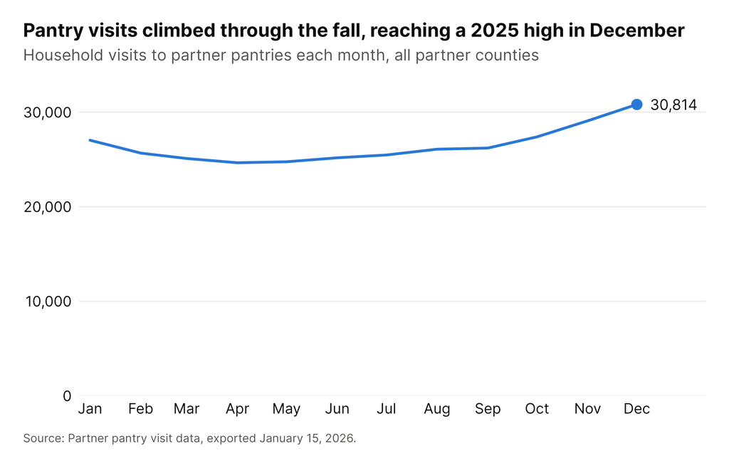

## Visits per resident varied widely by county

Four counties (Multnomah, Marion, Jackson, and Lane) had between 115 and 128 visits per 1,000 residents. The other four had between 76 and 87. Comparing per resident, rather than by raw totals, keeps the largest counties from dominating the picture.

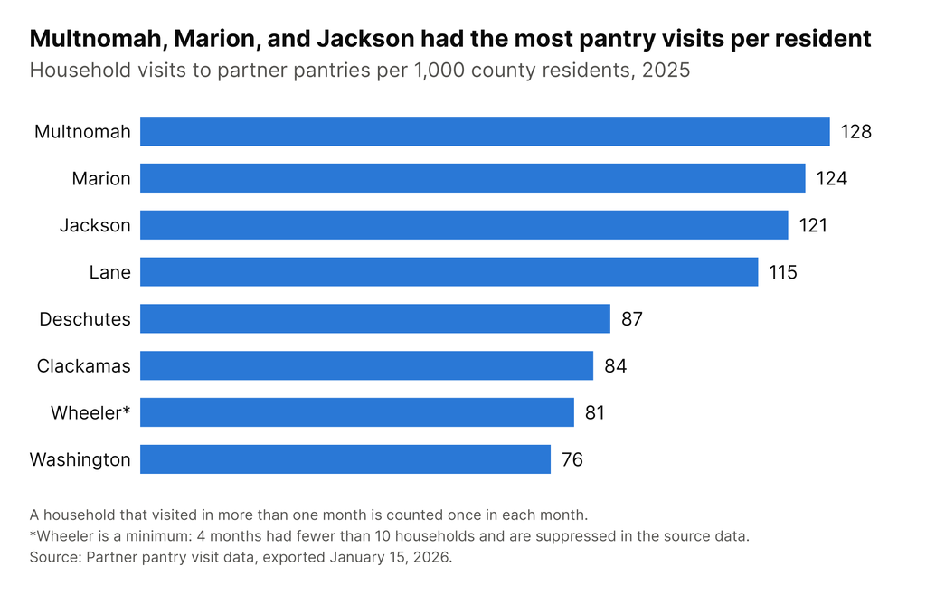

## About these numbers

- **Visits, not unique households.** Pantries report how many households they serve each month. A household that visits in several months is counted once in each month, so these figures count visits rather than distinct households.
- **Partner counties only.** The figures cover the 8 counties with partner pantries, not the whole state.
- **Small counts are suppressed.** Months with fewer than 10 households are withheld in the source data. This affects 4 months in Wheeler County, so its figures are a minimum.
- **Correction to an earlier draft.** An earlier version of this analysis reported 361,886 visits. It counted Lane County’s 44,480 visits twice because of a duplicate entry in the population file. The corrected total is 317,406.

Source: Partner pantry visit data, exported January 15, 2026. County populations are rounded estimates.